# M2 Lab Template

Ally Tirendi

```r
library(tidyverse)
```

# Part 1

## Probability of clinicially significant decline for placebo

```r
# placebo group probability
pnorm(-2,mean = -1.8, sd = 4.3)
```

```
## [1] 0.4814512
```

There is a ~48.1% chance that a randomly selected woman in the placebo group shows a clinically significant decline in bone-mineral density meaning a decline of 2% or more.

## Probability of clinicially significant decline for treatment

```r
# treatment group probability
pnorm(-2,mean=3.5,sd=4.2)
```

```
## [1] 0.09517849
```

There is a ~9.5% chance that a randomly selected woman in the treatment group shows a clinically significant decline in bone-mineral density.

## Probability of average among 50 placebo being clinicially significant decline

Central Limit Theorem conditions: Yes, change in bone mineral density is normally distributed. Since the population follows a normal distribution, we do not need a large sample size.

```r
# probability calculations

# given mean
mu = -1.8

# given standard deviation
sig = 4.3

# sample size
n = 50

#probability

pnorm(-2, mean = mu, sd = sig/sqrt(n))
```

```
## [1] 0.3711206
```

The probability of the mean of 50 women in the placebo group being in a clinically significant decline in bone mineral density using the Central Limit Theorem (CLT) is ~37.1%. This probability is lower compared to my answer in part A for a randomly selected woman (~48.1%).

# Part 2

## Data filtering

```r
# load data
bm = read_csv("Data/bm.csv")
# filter to only keep rows from code 871


bm = bm %>%
  filter(DRG_Cd == 871)
```

## Distribution of medical expenditure variable

```r
# mean
mean(bm$Avg_Mdcr_Pymt_Amt)
```

```
## [1] 13207.02
```

```r
# standard deviation
sd(bm$Avg_Mdcr_Pymt_Amt)
```

```
## [1] 4780.852
```

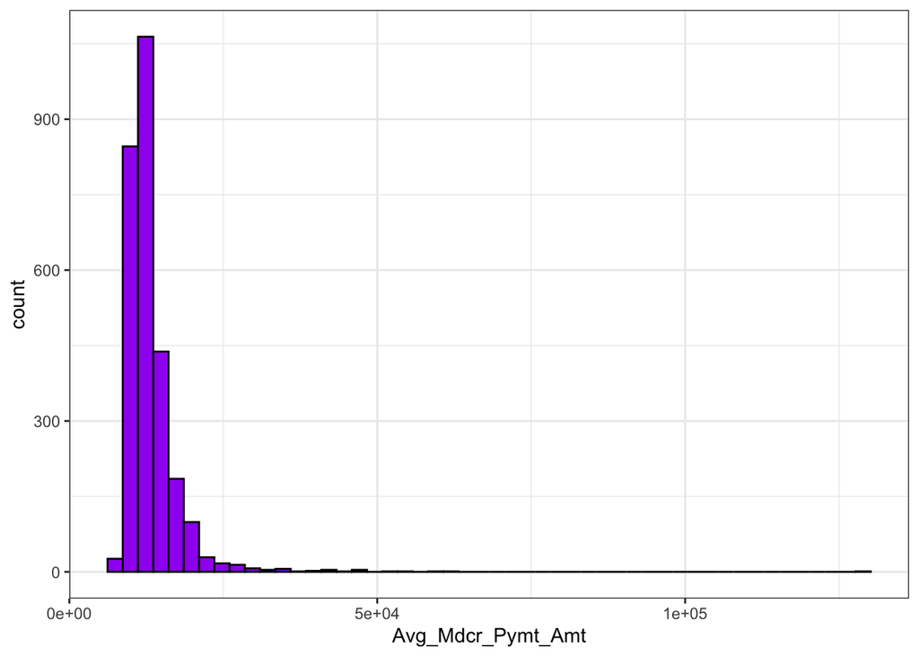

```r
# histogram
bm %>%
  drop_na(Avg_Mdcr_Pymt_Amt) %>%
  ggplot(aes(x= Avg_Mdcr_Pymt_Amt)) +
  geom_histogram(fill = "purple", color = "black", bins=50) +
  theme_bw()
```

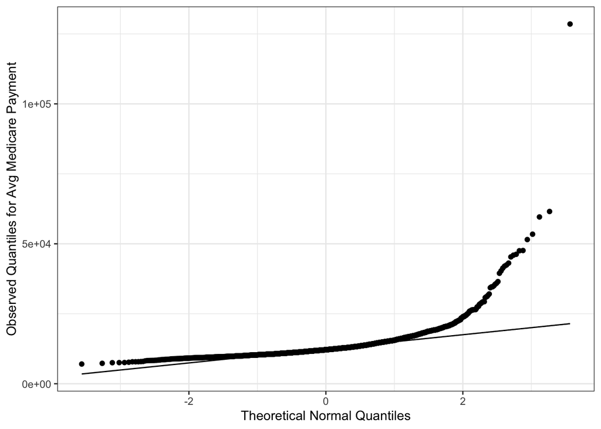

```r
# QQ-plot
bm %>%
  ggplot(aes(sample = Avg_Mdcr_Pymt_Amt)) +
  stat_qq() +
  stat_qq_line() +
  theme_bw() +
  labs(x = "Theoretical Normal Quantiles",
       y = "Observed Quantiles for Avg Medicare Payment")
```

Mean = 13207.02 SD= 4780.852

Judging from both the histogram and the QQ-plot, it appears the average payments do not come from a population with a normal distribution. The histogram shows a right-skewed distribution, and the QQ-Plot further demonstrates the data is right-skewed as it is U-shaped.

## Bootstrap Procedure

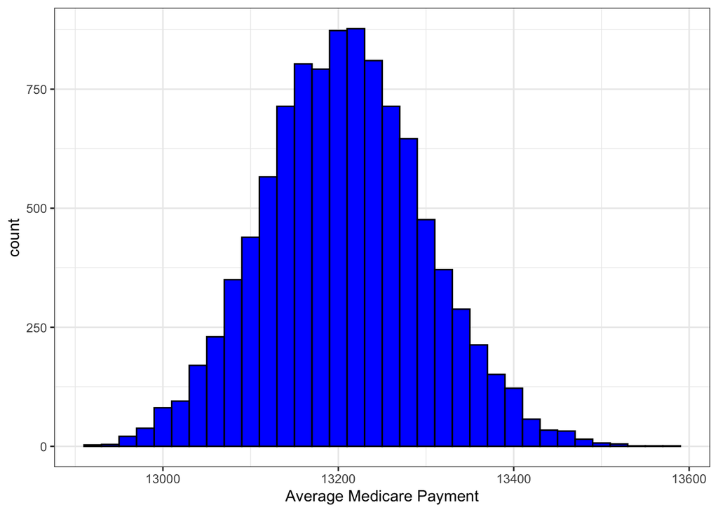

```r
# vector to save first bootstrap sample
set.seed(345)

bm.boot = bm %>% drop_na(Avg_Mdcr_Pymt_Amt)

bootstrap = data.frame(mean = rep(NA, 10000))

first_bootstrap_sample = NULL

for(i in 1:10000){
  samp = sample(bm.boot$Avg_Mdcr_Pymt_Amt, size = nrow(bm.boot), replace = T)

if(i == 1){
  first_bootstrap_sample = samp
}

# vector to save bootstrap means
  bootstrap$mean[i] = mean(samp)
}

# save first bootstrap sample in data frame
first_bootstrap_df = data.frame(first_bootstrap_sample)

# run boostrap procedure
bootstrap %>%
  ggplot(aes(x = mean)) +
  geom_histogram(fill = "blue", color = "black", binwidth = 20) +
  theme_bw() +
  labs(x = "Average Medicare Payment")
```

## Distribution of first bootstrap sample

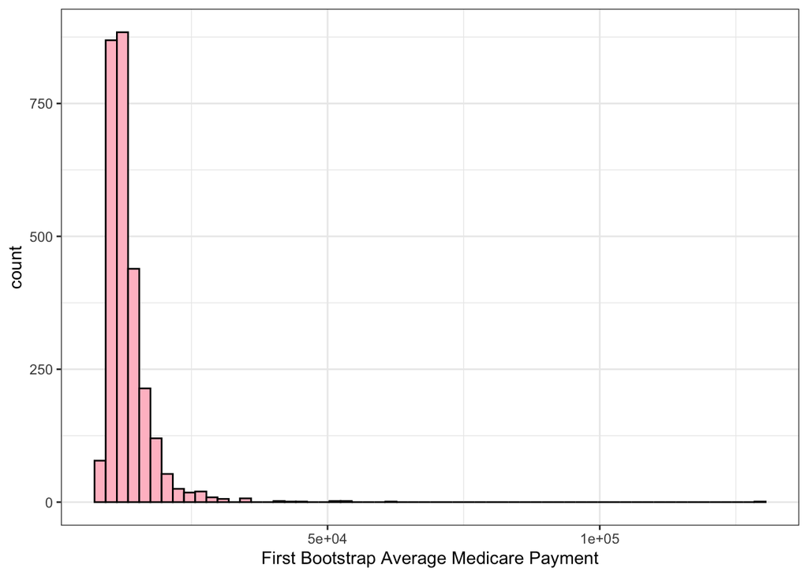

```r
# histogram
first_bootstrap_df %>%
  ggplot(aes(x= first_bootstrap_sample)) +
  geom_histogram(fill = "pink", color = "black", bins = 60) +
  theme_bw() +
  labs(x = "First Bootstrap Average Medicare Payment")
```

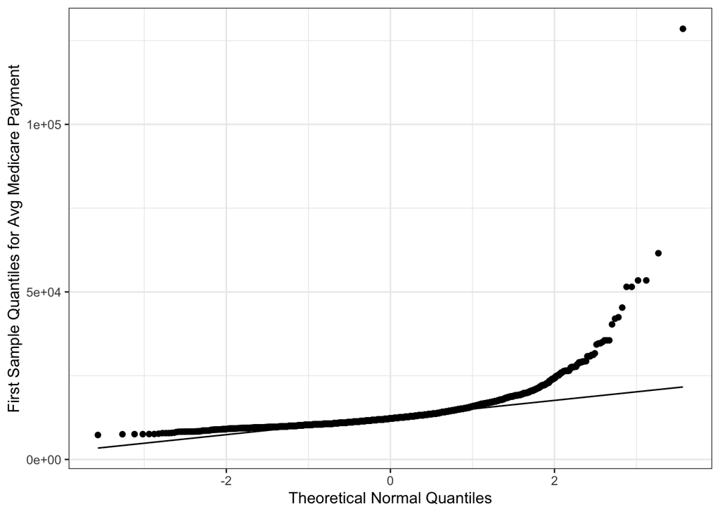

```r
# QQ plot
first_bootstrap_df %>%
  ggplot(aes(sample = first_bootstrap_sample)) +
  stat_qq() +
  stat_qq_line() +
  theme_bw() +
  labs(x = "Theoretical Normal Quantiles",
       y = "First Sample Quantiles for Avg Medicare Payment")
```

```r
# mean and standard deviation in first bootstrap sample
first_bootstrap_df %>%
  summarise(mn = mean(first_bootstrap_sample),
            se = sd(first_bootstrap_sample))
```

| mn | se |
| --- | --- |
| 13238.63 | 4661.347 |

Mean: 13238.63 SE: 4661.347

The distribution of the first bootstrap sample is still skewed to the right as both the histogram and QQ_Plot show a right-skewed distribution. Furthermore, the mean is very similar (not exact) to the our original data, but the standard deviation of the first bootstrap sample is slightly lower than the original data.

## Distribution of bootstrap means

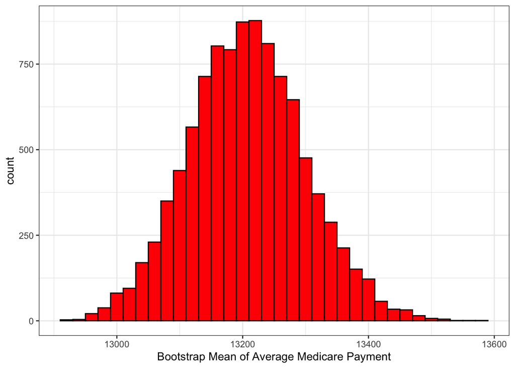

```r
# histogram
bootstrap %>%
  ggplot(aes(x = mean )) +
  geom_histogram(fill = "red", color = "black", binwidth = 20) +
  theme_bw() +
  labs(x = "Bootstrap Mean of Average Medicare Payment")
```

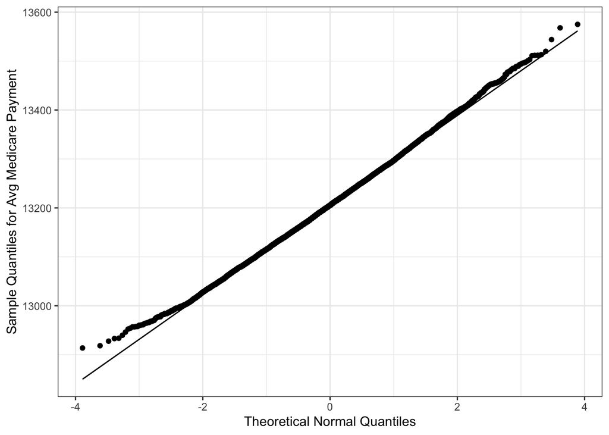

```r
# QQ plot
bootstrap %>%
  ggplot(aes(sample = mean)) +
  stat_qq() +
  stat_qq_line() +
  theme_bw() +
  labs(x = "Theoretical Normal Quantiles",
       y = "Sample Quantiles for Avg Medicare Payment")
```

```r
# mean and standard deviation of bootstrap means
bootstrap %>%
  summarise(mn = mean(mean),
            se = sd(mean))
```

| mn | se |
| --- | --- |
| 13206.89 | 91.69471 |

Mean: 13206.89 SE: 91.69

## Confidence interval from bootstrap

```r
# 95% confidence interval

quantile(bootstrap$mean, c(0.025,0.975))
```

```
##     2.5%    97.5%
## 13031.38 13393.84
```

```r
mean(bm.boot$Avg_Mdcr_Pymt_Amt) + c(-1,1)*qnorm(0.975)*sd(bm.boot$Avg_Mdcr_Pymt_Amt)/sqrt(nrow(bm.boot))
```

```
## [1] 13028.40 13385.64
```

From this calculation, I am not willing to believe that the true population mean average medicare payment for someone with this DRG code is $11,000. After constructing a 95% confidence interval, I am 95% confident that the true population mean lies between $13,031.38 and $13,393.84. Since, $11,000 does not fall within in this interval I would reject the null hypothesis.